# CES: Comparing Opinions of the Economy between the Differently Employed

Ting Hsu

2020-09-22

# Abstract

Using data from the 2019 Canadian Elections Study, three different questions about the economy and given to people of different employment statuses (Students, Retired, Part Time, Full Time, Unemployed, and Disabled), and their opinions are compared. The data is then organized with the goal to see if there will be major differences in opinion between people of different employment status. It seems that people tend to not think the economy is better, and think it is mostly worse off.

# Introduction

Is the Canadian economy in recession? I am not the expert on this subject. However, the Canadian Election Survey have collected information from 37822 people about their opinion, and I can organize their opinions to get a general idea as to what people THINK about the economy. The survey contains a myriad of questions such as employment status, religion, and income. This report looks at how might employment status affect the people’s opinion on how well the economy is doing.

There are three sections of the survey that will be compared, and they are:

- econ_retro: How people felt the economy have been in the past year.
- econ_fed: If people think that the government have made an impact on the economy - whether it is positive or negative.
- econ_self: How did people feel the effects of the government policies economically.

Through the exploration of data, I found that unemployed and disabled people are more likely, according to this survey, to view the economy to be worse. Though a significant portion of them still think that there are no significant differences. Most importantly, at any given time only a minority in any group think that the economy is getting better.

This is only a preliminary analysis of the data, and no statistical model have been fitted to match the data. Mainly because the study is done on categorical data with only four different choices. Which means that fitting a statistical model is an improvement that can be made, and of course, a weakness in itself also. Regardless, another possible area that can be explored is other factors that may affect people’s opinion on the economy.

# Data

Of 37822 people, 2456 of them did not fill in the data and therefore are not considered as part of the following graphs. In the survey, the students are split into Students and Students with Pay, but they are combined in this report as simply “Student”.

Here are the general numbers:

- Total amount of Students: 1314
- Total amount of Part Timers: 3415
- Total amount of Full Timers: : 16124
- Total amount of Retired: 9008
- Total amount of Unemployed: 1676
- Total amount of Disabled: 1312
- Total amount of Self Employed: 2517

### People’s View of the Economy over the Past Year

*Figures are numbered from top to bottom, and left to right. As in, Student’s Opinion -> Part Time -> Full Time -> Retired -> Unemployed -> Disabled -> Self Employed*

*Fig. 1 ~ 7*

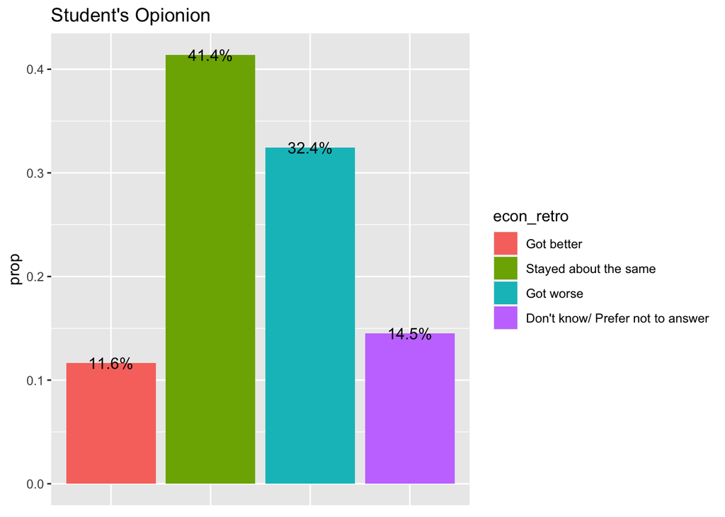

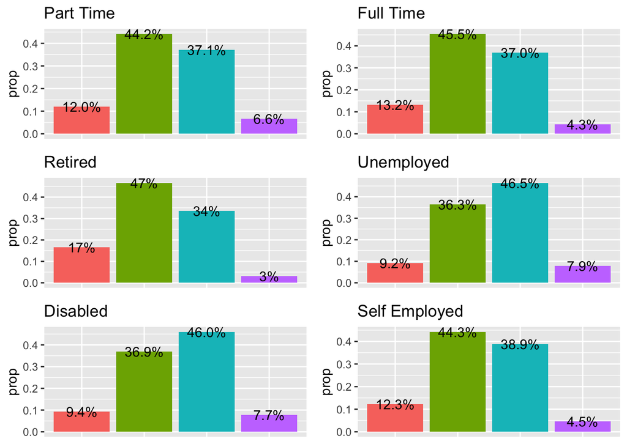

- The average difference between “Got Worse” and “Got Better”: 26.7428571%

### People’s View of the Government’s Work on the Economy

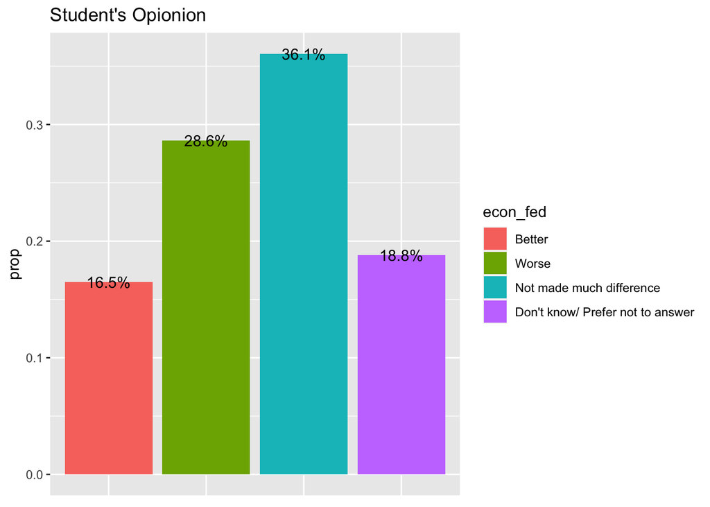

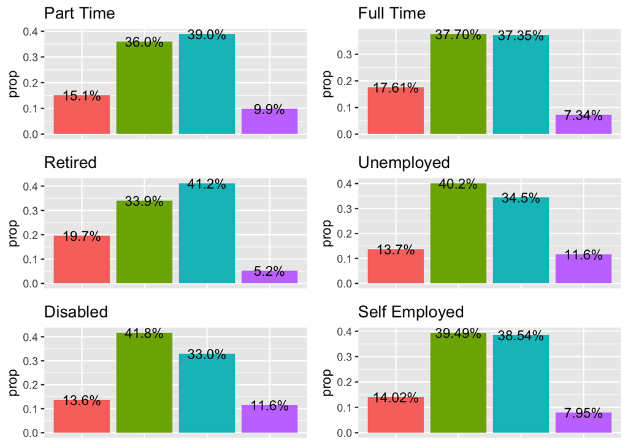

- The average difference between Worse and Better: 21.0657143%

### Government’s Policies’ Effect on People

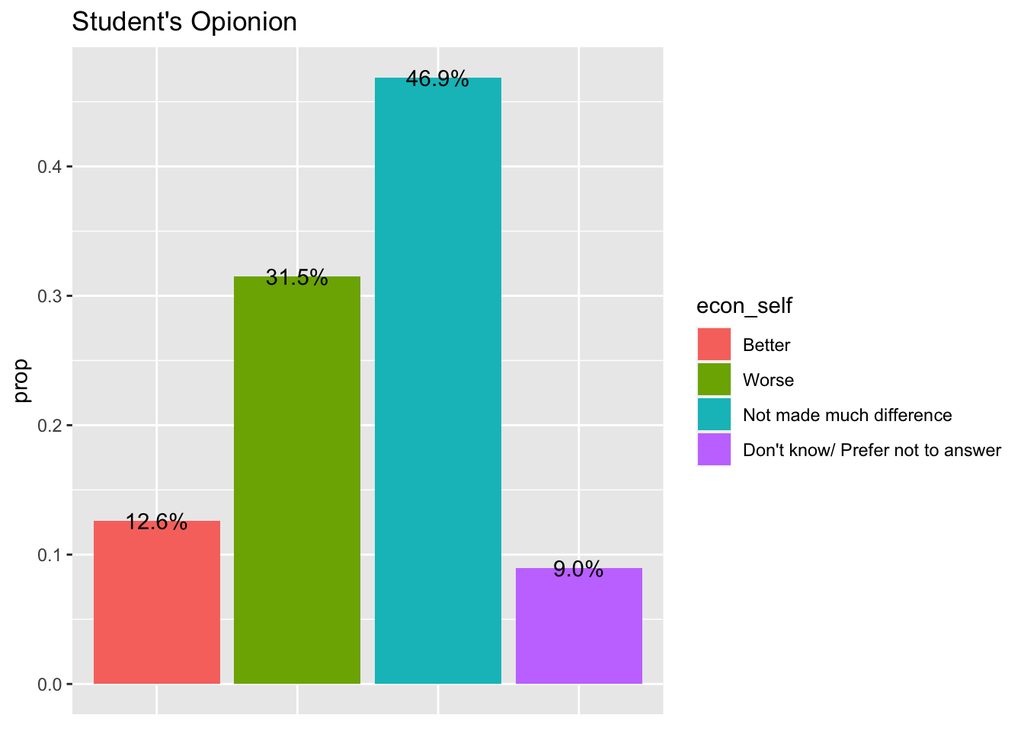

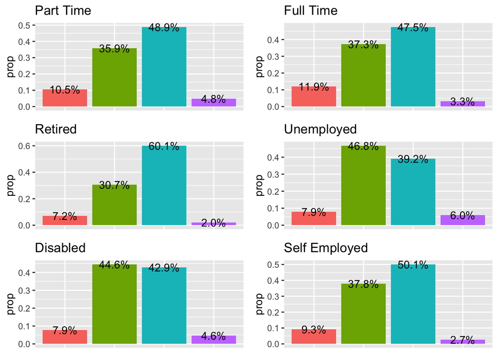

- The average difference between “Better” and “Worse”: 28.1857143%

# Discussion

The main theme across Fig. 1-7 are that everyone except for the unemployed and the disabled people share similar opinions of economy, with roughly 10% of Disabled and Unemployed people are shifted towards “Got Worse” as compared to "Stayed about the same.

This survey is conducted online, and it has many columns containing non-responses. None responses are shown as a gray column in the figure below. However, the columns used are the ones that are mostly in green, meaning that there’s a response.

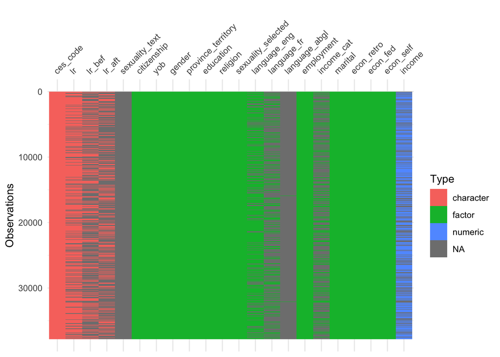

## Weaknesses and next steps

The statistical means calculated in the data sections are not weighted, which meant that the smaller populations like unemployed have the same weight in calculating the average as the full time workers, which make up almost half of all the data point. Also, as mentioned before there are no statistical models fitted to this report, and the analysis done is mostly rudimentary.

Possible next steps can be to dig further into the data and:

- Put a weight on each employment area based on amount of people
- Find another variable that may tie employment type to their opinion
- Fit a model where possible

# References

- Stephenson, Laura B; Harell, Allison; Rubenson, Daniel; Loewen, Peter John, 2020, ‘2019 Canadian Election Study - Online Survey’, https://doi.org/10.7910/DVN/DUS88V, Harvard Dataverse, V1
- Paul A. Hodgetts and Rohan Alexander (2020). cesR: Access the CES Datasets a Little Easier.. R package version 0.1.0.
- Hadley Wickham, Jim Hester and Winston Chang (2020). devtools: Tools to Make Developing R Packages Easier. https://devtools.r-lib.org/,https://github.com/r-lib/devtools.
- R Core Team (2020). R: A language and environment for statistical computing. R, Foundation for Statistical Computing, Vienna, Austria. URL, https://www.R-project.org/.
- JJ Allaire and Yihui Xie and Jonathan McPherson and Javier Luraschi and Kevin Ushey and Aron Atkins and Hadley Wickham and Joe Cheng and Winston Chang and Richard Iannone (2020). rmarkdown: Dynamic Documents for R. R package version 2.3. URL https://rmarkdown.rstudio.com.
- Stephenson, Laura B; Harell, Allison; Rubenson, Daniel; Loewen, Peter John, 2020, ‘2019 Canadian Election Study - Online Survey’, https://doi.org/10.7910/DVN/DUS88V, Harvard Dataverse, V1
- Baptiste Auguie (2017). gridExtra: Miscellaneous Functions for “Grid” Graphics. R package version 2.3. https://CRAN.R-project.org/package=gridExtra